# ANALISIS POLA PENYEWAAN FILM BERDASARKAN KATEGORI DAN DURASI

Annisa Cahyaningtyas - M0724048

26 May 2026

# 1 Pendahuluan

## 1.1 Latar Belakang

Industri penyewaan film adalah salah satu sektor dalam hiburan yang memiliki dinamika bisnis yang menarik untuk dianalisis. Setiap film memiliki ciri khas masing-masing, mulai dari jenis genre, lama penayangan, hingga biaya sewa yang ditetapkan. Variasi karakteristik ini diduga memengaruhi jumlah penyewaan dan pendapatan yang diperoleh setiap film.

Mendalami pola penyewaan film secara mendetail merupakan langkah penting bagi usaha rental. Dengan mengetahui kategori genre film yang paling diminati, apakah durasi film berpengaruh terhadap tarif sewa, serta faktor-faktor yang dapat meningkatkan pendapatan, manajemen dapat membuat keputusan bisnis yang paling tepat, misalnya dalam pengadaan film, penentuan harga, dan strategi pemasaran.

Oleh karena itu, analisis ini bertujuan untuk menyelidiki pola penyewaan film berdasarkan kategori genre, menganalisis hubugan antara durasi film dan tarif sewa, serta menguji perbedaan tarif sewa terhadap jumlah penyewaan. Hasil dari analisis ini diharapkan dapat memberikan wawasan yang bermanfaat untuk mendukung keputusan bisnis yang berbasis data pada industri penyewaan film.

## 1.2 Tujuan Analisis

Analisis ini dilakukan dengan tujuan sebagai berikut:

1. Mendeskripsikan distribusi film berdasarkan kategori genre pada database Sakila untuk mengetahui kategori mana yang paling banyak tersedia.
2. Menguji apakah terdapat hubungan yang signifikan antara durasi film (`length`) dan tarif sewa (`rental_rate`).
3. Menguji apakah terdapat perbedaan yang signifikan pada tarif sewa (`rental_rate`) antar kategori film.
4. Menganalisis pengaruh durasi film (`length`) dan tarif sewa (`rental_rate`) secara bersama-sama terhadap jumlah penyewaan (`rental_count`).
5. Memberikan rekomendasi berbasis data kepada manajemen bisnis penyewaan film dalam merancang strategi pengadaan film dan penetapan harga yang lebih optimal.

# 2 Deskripsi Data

Dataset yang digunakan dalam analisis ini berasal dari **database Sakila**, sebuah contoh database yang disediakan oleh MySQL dan sering dijadikan sebagai studi kasus dalam pembelajaran basis data. Database ini menggambarkan suatu sistem penyewaan film fiktif dan memuat informasi lengkap mengenai film, pelanggan, transaksi penyewaan, inventaris, serta staf.

Data yang diambil untuk analisis ini meliputi variabel `film`, `film_category`, `category`, dan `rental`, yang kemudian digabungkan menggunakan *join* untuk membentuk satu dataset terpadu.

## 2.1 Koneksi dan Query Database

```r
# Library
library(DBI)
library(RMySQL)
library(dplyr)
library(kableExtra)
library(gridExtra)
library(ggplot2)

# Koneksi MySQL
con <- dbConnect(
  MySQL(),
  dbname   = "sakila",
  host     = "127.0.0.1",
  port     = 3306,
  user     = "root",
  password = "tyas159"
)

# Query: menggabungkan film, kategori, inventory dan data rental
query <- "
SELECT
    f.film_id,
    f.title,
    c.name AS category,
    f.length,
    f.rental_rate,
    f.rating,
    f.replacement_cost,
    COUNT(r.rental_id) AS rental_count
FROM film f
JOIN film_category fc
    ON f.film_id = fc.film_id
JOIN category c
    ON fc.category_id = c.category_id
LEFT JOIN inventory i
    ON f.film_id = i.film_id
LEFT JOIN rental r
    ON i.inventory_id = r.inventory_id
GROUP BY
    f.film_id,
    f.title,
    c.name,
    f.length,
    f.rental_rate,
    f.rating,
    f.replacement_cost
"

data <- dbGetQuery(con, query)
dbDisconnect(con)
```

```
## [1] TRUE
```

## 2.2 Pratinjau Data

```r
data %>%
  head(15) %>%
  knitr::kable(
    caption = "15 Baris Pertama Dataset Sakila (Gabungan Film dan Rental)"
  ) %>%
  kable_styling(
    bootstrap_options = c("striped", "hover", "condensed"),
    full_width = FALSE
  ) %>%
  scroll_box(
    width = "100%",
    height = "320px"
  )
```

15 Baris Pertama Dataset Sakila (Gabungan Film dan Rental)

| film_id | title | category | length | rental_rate | rating | replacement_cost | rental_count |
| --- | --- | --- | --- | --- | --- | --- | --- |
| 19 | AMADEUS HOLY | Action | 113 | 0.99 | PG | 20.99 | 21 |
| 21 | AMERICAN CIRCUS | Action | 129 | 4.99 | R | 17.99 | 22 |
| 29 | ANTITRUST TOMATOES | Action | 168 | 2.99 | NC-17 | 11.99 | 10 |
| 38 | ARK RIDGEMONT | Action | 68 | 0.99 | NC-17 | 25.99 | 0 |
| 56 | BAREFOOT MANCHURIAN | Action | 129 | 2.99 | G | 15.99 | 18 |
| 67 | BERETS AGENT | Action | 77 | 2.99 | PG-13 | 24.99 | 21 |
| 97 | BRIDE INTRIGUE | Action | 56 | 0.99 | G | 24.99 | 19 |
| 105 | BULL SHAWSHANK | Action | 125 | 0.99 | NC-17 | 21.99 | 16 |
| 111 | CADDYSHACK JEDI | Action | 52 | 0.99 | NC-17 | 17.99 | 16 |
| 115 | CAMPUS REMEMBER | Action | 167 | 2.99 | R | 27.99 | 19 |
| 126 | CASUALTIES ENCINO | Action | 179 | 4.99 | G | 16.99 | 9 |
| 130 | CELEBRITY HORN | Action | 110 | 0.99 | PG-13 | 24.99 | 24 |
| 162 | CLUELESS BUCKET | Action | 95 | 2.99 | R | 13.99 | 25 |
| 194 | CROW GREASE | Action | 104 | 0.99 | PG | 22.99 | 12 |
| 205 | DANCES NONE | Action | 58 | 0.99 | NC-17 | 22.99 | 14 |

Berikut adalah penjelasan dari setiap variabel dalam dataset:

1. `film_id` : ID unik setiap film
2. `title` : Judul film
3. `category` : Kategori/genre film
4. `length` : Durasi film dalam menit
5. `rental_rate` : Tarif sewa per periode (dalam USD)
6. `rating` : Rating film (G, PG, PG-13, R, NC-17)
7. `replacement_cost` : Biaya penggantian jika film hilang/rusak
8. `rental_count` : Jumlah total penyewaan per film (dihitung dari agregasi variabel `rental`)

# 3 Eksplorasi Data

Eksplorasi data dilakukan untuk memahami struktur dan kondisi data sebelum masuk ke analisis lebih lanjut. Langkah ini meliputi pemeriksaan tipe data, *missing value*, dan statistik deskriptif untuk memastikan bahwa data yang digunakan sudah bersih dan siap untuk dianalisis.

## 3.1 Tipe data

```r
str(data)
```

```
## 'data.frame':    1000 obs. of  8 variables:
##  $ film_id         : num  19 21 29 38 56 67 97 105 111 115 ...
##  $ title           : chr  "AMADEUS HOLY" "AMERICAN CIRCUS" "ANTITRUST TOMATOES" "ARK RIDGEMONT" ...
##  $ category        : chr  "Action" "Action" "Action" "Action" ...
##  $ length          : num  113 129 168 68 129 77 56 125 52 167 ...
##  $ rental_rate     : num  0.99 4.99 2.99 0.99 2.99 2.99 0.99 0.99 0.99 2.99 ...
##  $ rating          : chr  "PG" "R" "NC-17" "NC-17" ...
##  $ replacement_cost: num  21 18 12 26 16 ...
##  $ rental_count    : num  21 22 10 0 18 21 19 16 16 19 ...
```

Dataset ini berisi **1.000 observasi** dengan **8 variabel**, yang meliputi variabel bertipe `chr` untuk kolom teks (title, category, rating) dan variabel bertipe `num` untuk kolom numerik (film_id, length, rental_rate, replacement_cost, rental_count). Struktur data ini sudah sesuai untuk analisis selanjutnya.

## 3.2 Pemeriksaan Missing Value

```r
colSums(is.na(data))
```

```
##          film_id            title         category           length
##                0                0                0                0
##      rental_rate           rating replacement_cost     rental_count
##                0                0                0                0
```

Tidak ada *missing value* pada semua variabel dalam dataset. Ini menandakan bahwa data sudah lengkap dan siap untuk digunakan dalam analisis selanjutnya.

## 3.3 Statistik Deskriptif

Statistik deskriptif ilakukan untuk memperoleh gambaran keseluruhan tentang distribusi data numerik. Beberapa ukuran yang dihitung mencakup rata-rata, median, variansi, serta standar deviasi.

Rata-rata (*mean*) diperoleh dengan rumus:

$$\bar{x} = \frac{1}{n} \sum_{i=1}^{n} x_i$$

Variansi untuk mengukur penyebaran data terhadap rata-rata:

$$s^2 = \frac{1}{n-1} \sum_{i=1}^{n} (x_i - \bar{x})^2$$

Standar deviasi merupakan akar kuadrat dari variansi:

$$s = \sqrt{\frac{1}{n-1} \sum_{i=1}^{n} (x_i - \bar{x})^2}$$

```r
data_numerik <- data[ , sapply(data, is.numeric)]

stat_desk <- data.frame(
  Mean     = sapply(data_numerik, mean,   na.rm = TRUE),
  Median   = sapply(data_numerik, median, na.rm = TRUE),
  Variansi = sapply(data_numerik, var,    na.rm = TRUE),
  Std_Dev  = sapply(data_numerik, sd,     na.rm = TRUE)
)

stat_desk %>%
  knitr::kable(digits = 2,
               caption = "Statistik Deskriptif Variabel Numerik") %>%
  kable_styling(bootstrap_options = c("striped", "hover", "condensed"),
                full_width = FALSE) %>%
  scroll_box(width = "100%", height = "300px")
```

Statistik Deskriptif Variabel Numerik

|  | Mean | Median | Variansi | Std_Dev |
| --- | --- | --- | --- | --- |
| film_id | 500.50 | 500.50 | 83416.67 | 288.82 |
| length | 115.27 | 114.00 | 1634.29 | 40.43 |
| rental_rate | 2.98 | 2.99 | 2.71 | 1.65 |
| replacement_cost | 19.98 | 19.99 | 36.61 | 6.05 |
| rental_count | 16.04 | 16.00 | 53.99 | 7.35 |

## 3.4 Distribusi Film per Kategori

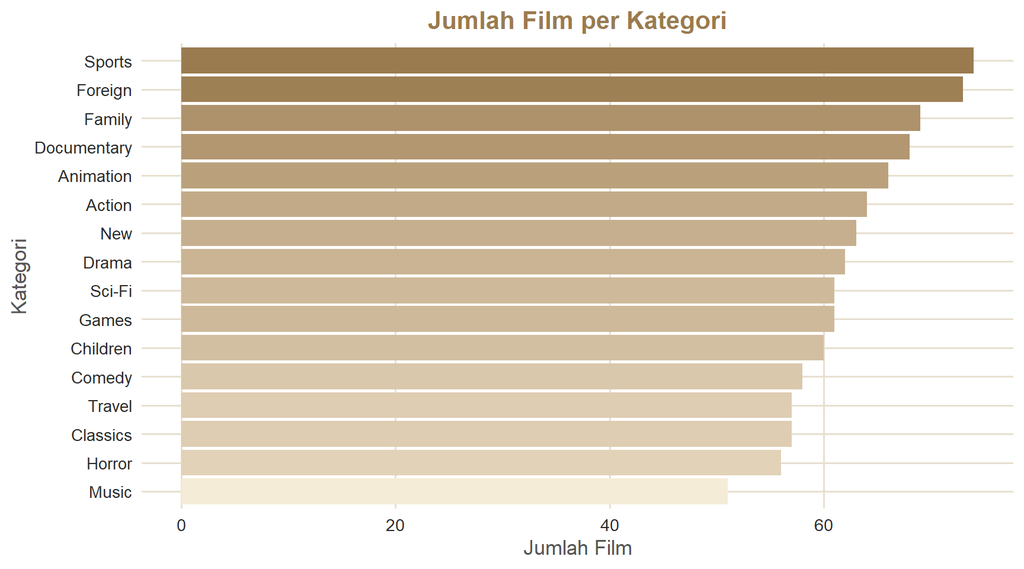

```r
data %>%
  count(category, sort = TRUE) %>%
  ggplot(aes(x = reorder(category, n), y = n, fill = n)) +
  geom_col(show.legend = FALSE) +
  scale_fill_gradient(low = "#F5ECD7", high = "#9A7B4F") +
  coord_flip() +
  labs(
    title = "Jumlah Film per Kategori",
    x     = "Kategori",
    y     = "Jumlah Film"
  ) +
  theme_minimal(base_size = 13) +
  theme(
    plot.title   = element_text(face = "bold", hjust = 0.5, color = "#9A7B4F"),
    axis.text    = element_text(color = "#2C2C2C"),
    axis.title   = element_text(color = "#555555"),
    panel.grid.major = element_line(color = "#E8E0D0"),
    panel.grid.minor = element_blank()
  )
```

# 4 Uji Statistik

Uji statistik dilakukan untuk menguji hubungan dan pengaruh antar variabel dalam dataset secara lebih detail. Sebelum melakukan uji lebih lanjut, dilakukan uji normalitas terlebih dahulu untuk menentukan jenis uji statistik yang akan digunakan di analisis berikutnya.

## 4.1 Uji Normalitas (Shapiro-Wilk)

Uji normalitas dilakukan untuk mengetahui apakah variabel `length`, `rental_rate`, dan `rental_count` berdistribusi normal atau tidak. Uji yang digunakan adalah Shapiro-Wilk dengan hipotesisi sebagai berikut:

$H_0$ : Data berdistribusi normal  
$H_1$ : Data tidak berdistribusi normal

```r
shapiro.test(data$length)
```

```
##
##  Shapiro-Wilk normality test
##
## data:  data$length
## W = 0.95598, p-value < 2.2e-16
```

```r
shapiro.test(data$rental_rate)
```

```
##
##  Shapiro-Wilk normality test
##
## data:  data$rental_rate
## W = 0.79048, p-value < 2.2e-16
```

```r
shapiro.test(data$rental_count)
```

```
##
##  Shapiro-Wilk normality test
##
## data:  data$rental_count
## W = 0.98741, p-value = 1.445e-07
```

Berdasarkan hasil uji Shapiro-Wilk, ketiga variabel, yaitu `length`, `rental_rate`, dan `rental_count` masing-masing memperoleh nilai W = 0,956; 0,790; dan 0,987 dengan p-value < 0,05. Sehingga, $H_0$ ditolak yang berarti bahwa ketiga variabel tersebut **tidak berdistribusi normal**. Karena asumsi normalitas tidak terpenuhi, maka analisis statistik yang akan digunakan selanjutnya adalah **Uji Korelasi Spearman** dan **Uji Kruskal-Wallis**.

Berikut visualisasi histogram untuk mendukung hasil uji normalitas.

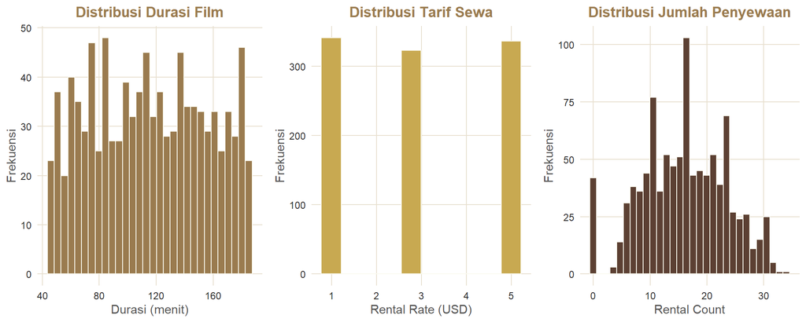

```r
tema_klasik <- theme_minimal() +
  theme(
    plot.title       = element_text(face = "bold", hjust = 0.5, color = "#9A7B4F"),
    axis.text        = element_text(color = "#2C2C2C"),
    axis.title       = element_text(color = "#555555"),
    panel.grid.major = element_line(color = "#E8E0D0"),
    panel.grid.minor = element_blank()
  )

p1 <- ggplot(data, aes(x = length)) +
  geom_histogram(fill = "#9A7B4F", color = "#FAFAF0", bins = 30) +
  labs(title = "Distribusi Durasi Film", x = "Durasi (menit)", y = "Frekuensi") +
  tema_klasik

p2 <- ggplot(data, aes(x = rental_rate)) +
  geom_histogram(fill = "#C8A951", color = "#FAFAF0", bins = 10) +
  labs(title = "Distribusi Tarif Sewa", x = "Rental Rate (USD)", y = "Frekuensi") +
  tema_klasik

p3 <- ggplot(data, aes(x = rental_count)) +
  geom_histogram(fill = "#5C4033", color = "#FAFAF0", bins = 30) +
  labs(title = "Distribusi Jumlah Penyewaan", x = "Rental Count", y = "Frekuensi") +
  tema_klasik

grid.arrange(p1, p2, p3, ncol = 3)
```

## 4.2 Uji Korelasi Spearman

Uji korelasi spearman dilakukan untuk melihat seberapa kuat hubungan antara durasi film (`length`) dan tarif sewa (`rental_rate`). Karena data tidak berdistribusi normal, maka digunakan uji Korelasi Spearman dengan hipotesis:

$H_0 : \rho = 0$ (Tidak terdapat hubungan antara durasi film dan biaya sewa)  
$H_1 : \rho \neq 0$ (Terdapat hubungan antara durasi film dan biaya sewa)

Interpretasi nilai $\rho$:  
$0{,}00 - 0{,}25$ : Korelasi sangat lemah  
$0{,}26 - 0{,}50$ : Korelasi cukup  
$0{,}51 - 0{,}75$ : Korelasi kuat  
$0{,}76 - 1{,}00$ : Korelasi sangat kuat

```r
cor.test(data$length, data$rental_rate, method = "spearman")
```

```
##
##  Spearman's rank correlation rho
##
## data:  data$length and data$rental_rate
## S = 161565208, p-value = 0.3336
## alternative hypothesis: true rho is not equal to 0
## sample estimates:
##        rho
## 0.03060778
```

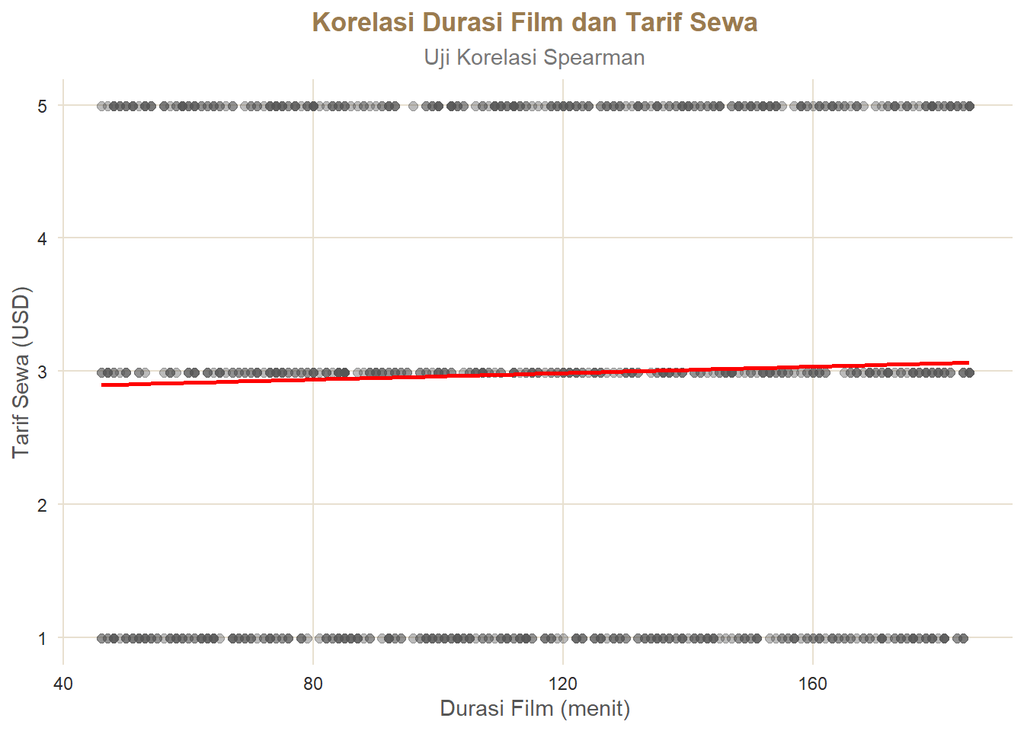

```r
ggplot(data, aes(x = length, y = rental_rate)) +
  geom_point(color = "#555555", alpha = 0.4, size = 2) +
  geom_smooth(method = "lm", color = "red", se = FALSE) +
  labs(
    title    = "Korelasi Durasi Film dan Tarif Sewa",
    subtitle = "Uji Korelasi Spearman",
    x        = "Durasi Film (menit)",
    y        = "Tarif Sewa (USD)"
  ) +
  theme_minimal() +
  theme(
    plot.title    = element_text(face = "bold", hjust = 0.5, color = "#9A7B4F"),
    plot.subtitle = element_text(hjust = 0.5, color = "#777777"),
    axis.text     = element_text(color = "#2C2C2C"),
    axis.title    = element_text(color = "#555555"),
    panel.grid.major = element_line(color = "#E8E0D0"),
    panel.grid.minor = element_blank()
  )
```

Berdasarkan hasil uji Korelasi Spearman, diperoleh nilai $\rho$ = 0,031 dengan p-value = 0,334 > 0,05, sehingga $H_0$ **gagal ditolak**. Artinya, **tidak terdapat hubungan yang signifikan** antara durasi film dan tarif sewa. Nilai $\rho$ = 0,031 menunjukkan adanya korelasi yang **sangat lemah**, yang juga terlihat dari penyebaran titik pada scatter plot yang tidak membentuk pola linear yang jelas. Hal ini menunjukkan bahwa penetapan tarif sewa pada database Sakila tidak dipengaruhi oleh durasi film.

## 4.3 Uji Kruskal-Wallis

Uji Kruskal-Wallis dilakukan untuk mengetahui apakah terdapat perbedaan yang signifikan pada tarif sewa (`rental_rate`) antar kategori film. Uji ini dipilih karena data yang tidak berdistribusi normal, sehingga tidak memenuhi syarat untuk melakukan uji ANOVA yang bersifat parametrik. Hipotesis yang digunakan:

$H_0$ : Tidak terdapat perbedaan tarif sewa antar kategori film  
$H_1$ : Terdapat perbedaan tarif sewa di setidaknya satu kategori film

```r
kruskal.test(rental_rate ~ category, data = data)
```

```
##
##  Kruskal-Wallis rank sum test
##
## data:  rental_rate by category
## Kruskal-Wallis chi-squared = 14.952, df = 15, p-value = 0.4549
```

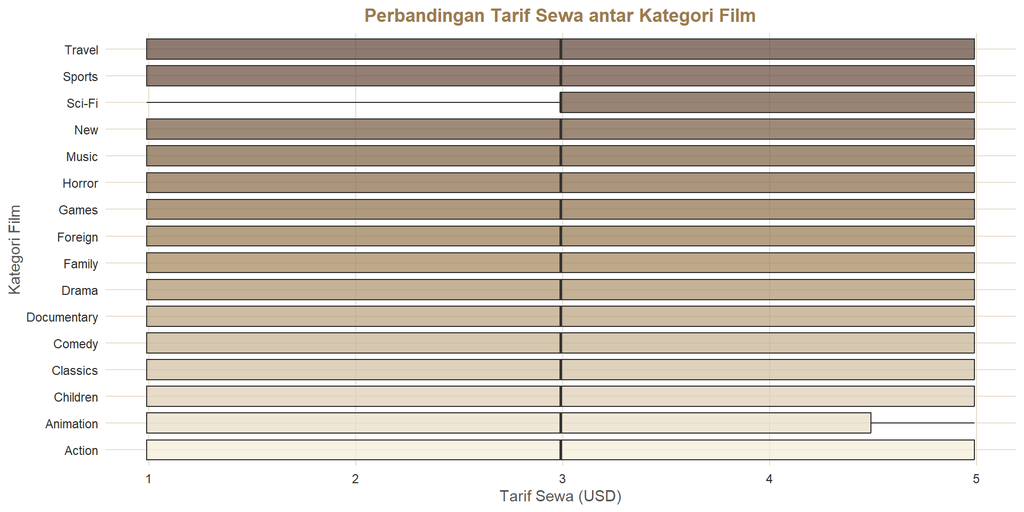

```r
ggplot(data, aes(x = reorder(category, rental_rate, median),
                 y = rental_rate, fill = category)) +
  geom_boxplot(alpha = 0.7, show.legend = FALSE) +
  scale_fill_manual(values = colorRampPalette(c("#F5ECD7", "#9A7B4F", "#5C4033"))(16)) +
  coord_flip() +
  labs(
    title = "Perbandingan Tarif Sewa antar Kategori Film",
    x     = "Kategori Film",
    y     = "Tarif Sewa (USD)"
  ) +
  theme_minimal() +
  theme(
    plot.title       = element_text(face = "bold", hjust = 0.5, color = "#9A7B4F"),
    axis.text        = element_text(color = "#2C2C2C"),
    axis.title       = element_text(color = "#555555"),
    panel.grid.major = element_line(color = "#E8E0D0"),
    panel.grid.minor = element_blank()
  )
```

Berdasarkan hasil uji Kruskal-Wallis, diperoleh nilai chi-squared = 14,952 dengan p-value = 0,455 > 0,05, sehingga $H_0$ **gagal ditolak**. Artinya, **tidak terdapat perbedaan yang signifikan** pada tarif sewa antar kategori film. Boxplot juga menunjukkan distribusi tarif sewa yang hampir konsisten di seluruh kategori dengan median yang serupa. Hal ini menunjukkan bahwa kebijakan penetapan tarif sewa dalam database Sakila bersifat konsisten dan tidak dipengaruhi oleh genre film.

## 4.4 Regresi Linear Berganda

Regresi linear berganda dilakukan untuk mengetahui seberapa besar pengaruh durasi film (`length`) dan tarif sewa (`rental_rate`) secara bersama-sama terhadap jumlah penyewaan (`rental_count`). Model yang digunakan adalah:

$$Y = \beta_0 + \beta_1 X_1 + \beta_2 X_2 + \varepsilon$$

Keterangan:  
$Y$ = Jumlah penyewaan (`rental_count`)  
$X_1$ = Durasi film (`length`)  
$X_2$ = Tarif sewa (`rental_rate`)  
$\beta_0$ = Konstanta (intersep) $\beta_1, \beta_2$ = Koefisien prediktor  
$\varepsilon$ = Error / residual

Hipotesis yang digunakan:  
$H_0: \beta_1 = \beta_2 = 0$ (Durasi film dan tarif sewa tidak berpengaruh signifikan terhadap jumlah penyewaan)  
$H_1$ : minimal satu $\beta_i \neq 0$ (Durasi film dan/atau tarif sewa berpengaruh signifikan terhadap jumlah penyewaan)

Walaupun data tidak berdistribusi normal, regresi linear tetap dapat digunakan karena jumlah data yang besar (n = 1.000). Berdasarkan *Central Limit Theorem*, distribusi estimator regresi akan mendekati normal pada sampel yang cukup besar, sehingga asumsi normalitas dianggap terpenuhi secara mendekati.

```r
model <- lm(rental_count ~ length + rental_rate, data = data)
summary(model)
```

```
##
## Call:
## lm(formula = rental_count ~ length + rental_rate, data = data)
##
## Residuals:
##      Min       1Q   Median       3Q      Max
## -16.6456  -5.4958   0.0422   5.3656  18.4448
##
## Coefficients:
##              Estimate Std. Error t value Pr(>|t|)
## (Intercept) 17.008126   0.808686  21.032   <2e-16 ***
## length      -0.002691   0.005751  -0.468    0.640
## rental_rate -0.219443   0.141222  -1.554    0.121
## ---
## Signif. codes:  0 '***' 0.001 '**' 0.01 '*' 0.05 '.' 0.1 ' ' 1
##
## Residual standard error: 7.346 on 997 degrees of freedom
## Multiple R-squared:  0.00268,    Adjusted R-squared:  0.0006794
## F-statistic:  1.34 on 2 and 997 DF,  p-value: 0.2624
```

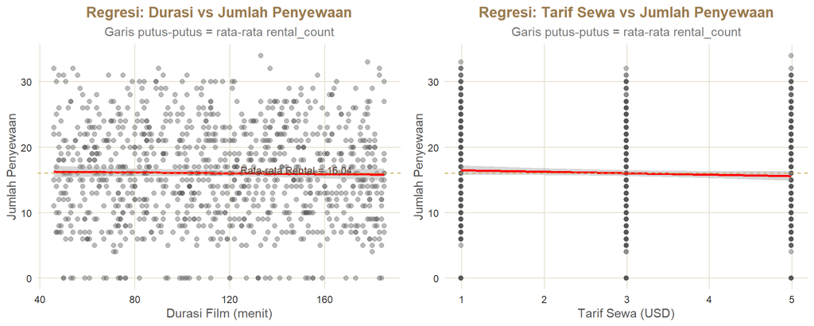

```r
tema_klasik <- theme_minimal() +
  theme(
    plot.title       = element_text(face = "bold", hjust = 0.5, color = "#9A7B4F"),
    plot.subtitle    = element_text(hjust = 0.5, color = "#777777"),
    axis.text        = element_text(color = "#2C2C2C"),
    axis.title       = element_text(color = "#555555"),
    panel.grid.major = element_line(color = "#E8E0D0"),
    panel.grid.minor = element_blank()
  )

p_len <- ggplot(data, aes(x = length, y = rental_count)) +
  geom_point(color = "#555555", alpha = 0.4, size = 1.8) +
  geom_smooth(method = "lm", color = "red", se = TRUE) +
  geom_hline(yintercept = mean(data$rental_count),
             linetype = "dashed", color = "#C8A951") +
  annotate("text",
           x     = max(data$length) * 0.80,
           y     = mean(data$rental_count) + 0.5,
           label = paste("Rata-rata Rental =",
                         round(mean(data$rental_count), 2)),
           size  = 3.2, color = "#5C4033") +
  labs(title    = "Regresi: Durasi vs Jumlah Penyewaan",
       subtitle = "Garis putus-putus = rata-rata rental_count",
       x = "Durasi Film (menit)", y = "Jumlah Penyewaan") +
  tema_klasik

p_rate <- ggplot(data, aes(x = rental_rate, y = rental_count)) +
  geom_point(color = "#555555", alpha = 0.4, size = 1.8) +
  geom_smooth(method = "lm", color = "red", se = TRUE) +
  geom_hline(yintercept = mean(data$rental_count),
             linetype = "dashed", color = "#C8A951") +
  labs(title    = "Regresi: Tarif Sewa vs Jumlah Penyewaan",
       subtitle = "Garis putus-putus = rata-rata rental_count",
       x = "Tarif Sewa (USD)", y = "Jumlah Penyewaan") +
  tema_klasik

grid.arrange(p_len, p_rate, ncol = 2)
```

Berdasarkan hasil regresi linear berganda, persamaan model yang terbentuk adalah:

$$\hat{Y} = 17{,}008 - 0{,}003\, X_1 - 0{,}219\, X_2$$

Interpretasi koefisien:

- $\beta_0$ = 17,008, ketika `length` dan `rental_rate` bernilai 0, prediksi `rental_count` adalah 17,008.
- $\beta_1$ = -0,003, setiap penambahan 1 menit durasi film, `rental_count` diprediksi **menurun** sebesar 0,003, dengan asumsi `rental_rate` tetap.
- $\beta_2$ = -0,219, setiap kenaikan tarif sewa sebesar 1 USD, `rental_count` diprediksi **menurun** sebesar 0,219, dengan asumsi `length` tetap.

Berdasarkan uji F, diperoleh nilai F-statistic = 1,34 dengan p-value = 0,262 > 0,05, sehingga $H_0$ **gagal ditolak** yang berarti `length` dan `rental_rate` secara bersama-sama **tidak berpengaruh signifikan** terhadap `rental_count`. Secara parsial, `length` memiliki p-value = 0,640 dan `rental_rate` memiliki p-value = 0,121, keduanya > 0,05 sehingga masing-masing variabel juga **tidak berpengaruh signifikan** secara individual terhadap `rental_count`.

Nilai *R-squared* sebesar 0,00268 menunjukkan bahwa hanya **0,27% variasi** `rental_count` yang dapat dijelaskan oleh kedua prediktor. Sisanya sebesar 99,73% dipengaruhi oleh faktor lain di luar model, seperti popularitas aktor, musim penyewaan, maupun ketersediaan stok film.

# 5 PENUTUP

## 5.1 Kesimpulan

Secara keseluruhan, analisis menunjukkan bahwa **durasi film dan tarif sewa bukan faktor utama** yang menentukan jumlah penyewaan film di database Sakila. Terdapat faktor-faktor lain di luar model yang lebih berpengaruh terhadap jumlah penyewaan, seperti popularitas aktor, musim penyewaan, dan juga ketersediaan stok film.

## 5.2 Rekomendasi

Berdasarkan hasil analisis, beberapa rekomendasi yang dapat diberikan kepada manajemen bisnis penyewaan film adalah sebagai berikut:

1. **Eksplorasi variabel lain yang lebih relevan** untuk memprediksi jumlah penyewaan, seperti:
- Popularitas aktor (`actor_id`) : film yang dibintangi oleh aktor terkenal biasanya mendapatkan banyak penyewa.
- Periode waktu penyewaan (`rental_date`) : pola musiman dapat membantu dalam rencana promosi.
- Ketersediaan stok (`inventory`) : jumlah salinan yang tersedia untuk setiap judul dapat memengaruhi peluang film tersebut disewa.
- Rating film (`rating`) : Sekelompok pelanggan tertentu mungkin lebih tertarik pada rating tertentu.
2. **Diversifikasi stok berdasarkan kategori** mengingat bahwa distribusi kategori tidak merata, manajemen sebaiknya mempertimbangkan untuk menambah stok pada kategori yang kurang terwakili namun berpotensi diminati pelanggan.